# The Electron Scattering Code 2

Xingzhuo "Gesa" Chen

This is also an example about the electron scattering radiative transfer calculation. Most of the code are the same as the previous one. I will illustrate the difference in this notebook.

By the way, the GPU memory requirement is now 19 GB, please check the hyper-parameter and your GPU before running the code.

```python
import os
import torch as t
import numpy as np
from torch import nn
from torch.optim import Adam
from astropy import units as u
import matplotlib.pyplot as plt
from astropy import constants as c
from torch.autograd import Variable
```

## The Neural Network

10 layers, tanh as activation.

```python
class Inten(nn.Module):
    def __init__(self):
        super(Inten, self).__init__()
        self.fc1=nn.Linear(4,128)
        self.fc2=nn.Linear(128,128)
        self.fc3=nn.Linear(128,128)
        self.fc4=nn.Linear(128,128)
        self.fc5=nn.Linear(128,128)
        self.fc6=nn.Linear(128,128)
        self.fc7=nn.Linear(128,128)
        self.fc8=nn.Linear(128,64)
        self.fc9=nn.Linear(64,32)
        self.fc10=nn.Linear(32,1)

    def forward(self,Xin):
        self.Xin=Xin
        out=nn.Tanh()(self.fc1(Xin))
        out=nn.Tanh()(self.fc2(out))
        out=nn.Tanh()(self.fc3(out))
        out=nn.Tanh()(self.fc4(out))
        out=nn.Tanh()(self.fc5(out))
        out=nn.Tanh()(self.fc6(out))
        out=nn.Tanh()(self.fc7(out))
        out=nn.Tanh()(self.fc8(out))
        out=nn.Tanh()(self.fc9(out))

        out=self.fc10(out)
        return out
```

```python
IntenNet=Inten().double().cuda()
```

```python
for i in IntenNet.parameters():
    if len(i.shape)<2:continue
    nn.init.kaiming_uniform_(i)
```

## The Optimizer

```python
optim=Adam(IntenNet.parameters(),lr=0.0002,betas=(0.5,0.999))
```

## The Collocation Points

This time, I add data points for the boundary condition, the number of boundary data points is defined in bounBatch.

```python
collBatch=3500
initBatch=3500
bounBatch=3500
batchNum=300
epochNum=2000
```

```python
sigmaT=c.sigma_T.to('cm^2').value #thompson cross section in cm^2
N=1e-10*6.02*10**23 #Number of electron per cm^3.
sig=sigmaT*N
cli=c.c.to('cm/s').value #speed of light in meter/second
zmax=1*cli
zmin=0*cli
tmax=1
```

## The Random Sampler

The sampling points for the boundary condition are located at z=0 boundary, and the angle is limited to $0<\varphi<0.5\pi$, so that these sampling points define the inflow radiation of the material.

```python
ztptOrig=np.random.random(collBatch*batchNum*4).reshape(-1,4)
ztptOrig=ztptOrig*np.array([1,np.pi*2,np.pi,1])+np.array([0,0,0,0])
ztptOrig=t.tensor(ztptOrig).cuda()
ztptOrig=ztptOrig.split(collBatch)
ztptOrig=[i for i in ztptOrig]

ztptInitOrig=np.random.random(initBatch*batchNum*4).reshape(-1,4)
ztptInitOrig=ztptInitOrig*np.array([1,np.pi*2,np.pi,0])+np.array([0,0,0,0])
ztptInitOrig=t.tensor(ztptInitOrig).cuda()
ztptInitOrig=ztptInitOrig.split(initBatch)
ztptInitOrig=[i for i in ztptInitOrig]

ztptBoun1Orig=np.random.random(initBatch*batchNum*4).reshape(-1,4)
ztptBoun1Orig=ztptBoun1Orig*np.array([0,np.pi*2,np.pi*0.5,1])+np.array([0,0,0,0])
ztptBoun1Orig=t.tensor(ztptBoun1Orig).cuda()
ztptBoun1Orig=ztptBoun1Orig.split(bounBatch)
ztptBoun1Orig=[i for i in ztptBoun1Orig]
```

## The Training

### The code

1. The loss function for the boundary condition is defined. Its weight is set to be 30.

```python
thetaIntStep=20# (1)
phiIntStep=20
thetaPhiInStep=thetaIntStep*phiIntStep
for epoch in range(epochNum):
    for batch in range(batchNum):

        ztpt=Variable(ztptOrig[batch].clone().detach(),requires_grad=True)
        IntenNet.zero_grad()
        IntenOut=IntenNet(ztpt).flatten()
        XinGrad=t.autograd.grad(t.sum(IntenOut),ztpt,retain_graph=True,create_graph=True)[0]
        XinGrad[:,0]=XinGrad[:,0]/(zmax-zmin) #(2)
        XinGrad[:,3]=XinGrad[:,3]/tmax

        thetaIn=np.linspace(0,2*np.pi,num=thetaIntStep)#(3)
        phiIn=np.linspace(0,np.pi,num=phiIntStep)
        thetaIn,phiIn=np.meshgrid(thetaIn,phiIn)
        thetaIn,phiIn=t.tensor(thetaIn).flatten().cuda(),t.tensor(phiIn).flatten().cuda()
        thetaInbig,zbig=t.meshgrid(thetaIn,ztpt[:,0])
        phiInbig,tbig=t.meshgrid(phiIn,ztpt[:,3])
        ztptBig=t.vstack([zbig.flatten(),thetaInbig.flatten(),phiInbig.flatten(),tbig.flatten()]).T

        IntenBig=IntenNet(ztptBig).flatten().reshape([thetaPhiInStep,-1])
        IntenBig=IntenBig.clone().detach()
        cosBetween=t.sin(thetaInbig)*t.sin(phiInbig)*t.sin(ztpt[:,1])*t.sin(ztpt[:,2])+t.cos(thetaInbig)*t.sin(phiInbig)*t.cos(ztpt[:,1])*t.sin(ztpt[:,2])+t.cos(phiInbig)*t.cos(ztpt[:,2])#(4)
        cosBetween=cosBetween.clone().detach()
        IntegSum=t.sum((1+cosBetween**2)/2*t.sin(phiInbig)*IntenBig,axis=0)/thetaPhiInStep*2*np.pi**2*1.5/4/np.pi
        IntegSum=IntegSum.clone().detach()#(5)

        lossEqu=XinGrad[:,3]/cli+t.cos(ztpt[:,2])*XinGrad[:,0]+sig*IntenOut-sig*IntegSum#(7)
        lossEqu=lossEqu**2
        curLosLis=lossEqu.clone().detach()


        if epoch%4!=0:#(8)


            lossEqu=t.sum(lossEqu)*1e20#(9)

            ztptInit=Variable(ztptInitOrig[batch].clone().detach(),requires_grad=True)
            IntenOutInit=IntenNet(ztptInit).flatten()
            lossInit=(IntenOutInit-0)**2
            lossInit=t.sum(lossInit)*30

            ztptBoun1=Variable(ztptBoun1Orig[batch].clone().detach(),requires_grad=True)
            IntenOutBoun1=IntenNet(ztptBoun1).flatten()
            lossBoun1=(IntenOutBoun1-1)**2
            lossBoun1=t.sum(lossBoun1)*30#(10)

            loss=lossEqu+lossInit+lossBoun1
            if batch%20==0:
                print(loss.item(),lossEqu.item(),lossInit.item(),lossBoun1.item())
            loss.backward()
            optim.step()






        if epoch%4==0:
            IntenNet.zero_grad()
            ztpt=np.random.random(collBatch*4).reshape(-1,4)
            ztpt=ztpt*np.array([1,np.pi*2,np.pi,1])+np.array([0,0,0,0])
            ztpt=t.tensor(ztpt).cuda()
            ztpt=Variable(ztpt,requires_grad=True)
            ztptNew=ztpt.clone().detach()

            IntenOut=IntenNet(ztpt).flatten()
            XinGrad=t.autograd.grad(t.sum(IntenOut),ztpt,retain_graph=True,create_graph=True)[0]
            XinGrad[:,0]=XinGrad[:,0]/(zmax-zmin)
            XinGrad[:,3]=XinGrad[:,3]/tmax

            thetaIn=np.linspace(0,2*np.pi,num=thetaIntStep)
            phiIn=np.linspace(0,np.pi,num=phiIntStep)
            thetaIn,phiIn=np.meshgrid(thetaIn,phiIn)
            thetaIn,phiIn=t.tensor(thetaIn).flatten().cuda(),t.tensor(phiIn).flatten().cuda()
            thetaInbig,zbig=t.meshgrid(thetaIn,ztpt[:,0])
            phiInbig,tbig=t.meshgrid(phiIn,ztpt[:,3])
            ztptBig=t.vstack([zbig.flatten(),thetaInbig.flatten(),phiInbig.flatten(),tbig.flatten()]).T

            IntenBig=IntenNet(ztptBig).flatten().reshape([thetaPhiInStep,-1])
            IntenBig=IntenBig.clone().detach()
            cosBetween=t.sin(thetaInbig)*t.sin(phiInbig)*t.sin(ztpt[:,1])*t.sin(ztpt[:,2])+t.cos(thetaInbig)*t.sin(phiInbig)*t.cos(ztpt[:,1])*t.sin(ztpt[:,2])+t.cos(phiInbig)*t.cos(ztpt[:,2])
            cosBetween=cosBetween.clone().detach()
            IntegSum=t.sum((1+cosBetween**2)/2*t.sin(phiInbig)*IntenBig,axis=0)/thetaPhiInStep*2*np.pi**2*1.5/4/np.pi
            IntegSum=IntegSum.clone().detach()

            lossEqu=XinGrad[:,3]/cli+t.cos(ztpt[:,2])*XinGrad[:,0]+sig*IntenOut-sig*IntegSum
            lossEqu=lossEqu**2
            nexLosLis=lossEqu.clone().detach()
            uniRand=t.tensor(np.random.random(len(ztpt))).cuda()
            ztptUpd=ztptOrig[batch].clone().detach()
            mask=(nexLosLis/curLosLis>uniRand)
            mask=mask.detach().cpu().numpy()
            ztptUpd[mask]=ztptNew[mask]
            ztptOrig[batch]=ztptUpd

    print('epoch '+str(epoch))
    #break
```

```
epoch 0
62.91498200809751 8.759497839435754 3.6118870680133393 50.54359710064842
60.55305935119587 8.149924572781725 49.5502206817733 2.8529140966408417
77.49816622977195 28.362535458930385 32.1583736868201 16.977257084021474
20.104739389666474 6.531326118458907 1.6562570430808747 11.917156228126693
39.63292162789389 6.327594952070378 17.837520708539348 15.467805967284168
37.02790025787388 10.531881204318859 5.143621441574883 21.35239761198014
42.973296820405594 7.381655547283554 1.8533787724303612 33.738262500691675
11.849526862984298 5.21947869070443 1.6047405957889467 5.0253075764909205
101.07699216638558 8.16792940984804 91.22846184796572 1.6806009085718174
23.13523441692749 4.153563345265756 11.207457570907552 7.774213500754181
103.82396470050212 11.539756693892452 76.93739222143344 15.346815785176213
55.82554820362495 5.437815740125045 49.61959245570409 0.7681400077958118
58.60493737500333 19.143156808546753 11.913228932268934 27.548551634187643
19.610526236679696 4.664124743279777 9.150562283906302 5.795839209493619
149.25165418197395 5.413058596961179 0.39392206239136596 143.4446735226214
epoch 1
66.14963937085686 6.491722428983388 57.98608641785337 1.6718305240200888
51.94719322614984 5.790737582990611 44.31430988570704 1.842145757452191
41.05944529257631 8.58683115283224 29.752176731924333 2.720437407819737
116.04895874917649 11.623738805799473 1.599678639250557 102.82554130412646
33.10422421156799 4.833039374560885 20.741206570585398 7.529978266421709
27.91722474134063 5.469962976073314 1.0324098468184961 21.414851918448818
29.9159080306649 14.213584333692966 0.3601423324959554 15.34218136447598
17.034336495876733 6.287867379613263 3.521380608131013 7.225088508132458
72.28374210524518 16.658618965371392 52.02371936331611 3.6014037765576723
44.588680730849546 4.947563370465312 30.33790238274466 9.303214977639579
77.95586387038995 8.419028445736984 46.88332576669026 22.6535096579627
65.48896219166615 5.528738793568114 59.30902686003264 0.6511965380653864
59.2237597457805 11.435183213956249 4.160976705957585 43.62759982586667
23.598984488822232 4.34849685176179 9.836953980589827 9.413533656470618
49.25092617199465 5.870162105845822 1.0894538080964105 42.29131025805242
epoch 2
110.10467128797345 9.097358972141334 100.08929408814068 0.9180182276914312
153.03498801068574 8.736900701964544 143.81867765286407 0.47940965585711154
42.70609121052314 9.016287319095714 29.59227473572927 4.097529155698153
194.36331048125214 15.117271019038636 0.4649807044928638 178.78105875772064
35.30576465874157 5.443052371226697 16.394531594225807 13.46818069328907
35.35977459242077 5.10554194779123 6.235177964282849 24.01905468034669
10.519994780116527 4.547743593730733 0.8993638855090635 5.07288730087673
```

[output cut: 80 more lines]

```
32.9557490716163 10.249977761338512 4.212064643959747 18.493706666318044
14.22888283013856 7.667704789350645 1.8739443383935759 4.68723370239434
12.328687337542679 6.9433417226203415 2.6588243123717294 2.7265213025506085
82.89039199719811 4.974338668233353 77.00537720260743 0.910676126357315
61.05760628157493 5.141224543296621 23.382796495441333 32.53358524283697
53.67662370019343 5.96062641055246 45.335649205269114 2.3803480843718603
58.627382918995345 6.684019971410015 50.94935442260162 0.9940085249837077
92.76683251051243 6.394240516955241 76.13515426601684 10.237437727540353
17.460813122188263 5.332012925703586 8.874705671886824 3.2540945245978525
24.553399579507527 5.062672022746764 4.777119343236461 14.713608213524301
epoch 10
64.1789638344383 8.489011933745337 51.90710493911385 3.782846961579112
43.63830177193908 12.785148446037539 25.83328395612552 5.019869369776025
18.84125024613778 6.31268592016991 3.2318071449415173 9.29675718102635
54.66539534527041 48.90725016958079 1.9625428692249853 3.795602306464641
```

[output not shown]

## The Result

### Light Propagation

The viewing angle is 0. At different z coordinates, the radiation intensity starts to increase at different time, and the speed of light is conserved. The final intensity is different at different z coordinate, because more lights are scattered with a larger distance.

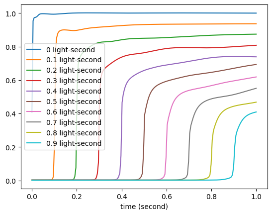

```python
plt.style.use('default')
ztpt=t.tensor(np.zeros([200,4]))
ztpt=ztpt.cuda()
for zloc in [0,0.1,0.2,0.3,0.4,0.5,0.6,0.7,0.8,0.9]:
    ztpt[:,0]=zloc
    ztpt[:,2]=0
    ztpt[:,3]=t.tensor(np.linspace(0,1,num=200)).float().cuda()
    plt.plot(np.linspace(0,1,num=200),IntenNet(ztpt).cpu().detach().numpy(),label=str(round(zloc,3))+' light-second')
plt.legend()
plt.xlabel('time (second)')
```

### Light Propagation 2

Here, the viewing angle is $\varphi=\pi/3$. At a given z coordinate, the radiation intensity starts to increase at the time $t=z/c$ (c is the speed of light), because the inflow light with $\varphi=0$ has reached the z coordinate and scattered into the $\varphi=\pi/3$ angle. Moreover, the radiation intensity increases significantly at the time $t=z/cos(\pi/3)/c$, because the inflow light with $\varphi=\pi/3$ has reached the z coordinate without scattering effect.

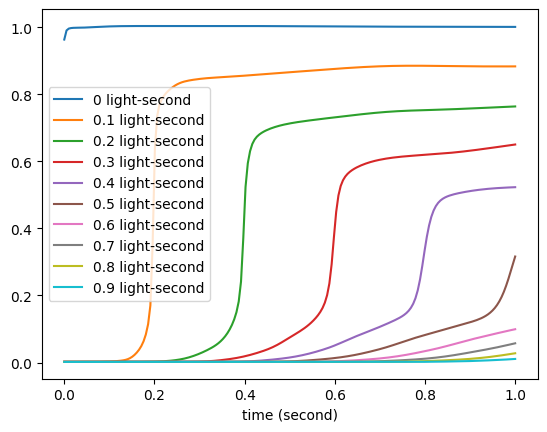

```python
plt.style.use('default')
ztpt=t.tensor(np.zeros([200,4]))
ztpt=ztpt.cuda()
for zloc in [0,0.1,0.2,0.3,0.4,0.5,0.6,0.7,0.8,0.9]:
    ztpt[:,0]=zloc
    ztpt[:,2]=np.pi/3
    ztpt[:,3]=t.tensor(np.linspace(0,1,num=200)).float().cuda()
    plt.plot(np.linspace(0,1,num=200),IntenNet(ztpt).cpu().detach().numpy(),label=str(round(zloc,3))+' light-second')
plt.legend()
plt.xlabel('time (second)')
```

### The Scattered Light

The viewing angle is $\varphi=\pi/2$, so there should be no light can be observed without scattering effect. The light observed in the figure are from the scattering effect.

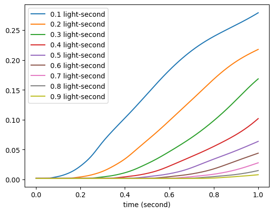

```python
plt.style.use('default')
ztpt=t.tensor(np.zeros([200,4]))
ztpt=ztpt.cuda()
for zloc in [0.1,0.2,0.3,0.4,0.5,0.6,0.7,0.8,0.9]:
    ztpt[:,0]=zloc
    ztpt[:,2]=np.pi/2
    ztpt[:,3]=t.tensor(np.linspace(0,1,num=200)).float().cuda()
    plt.plot(np.linspace(0,1,num=200),IntenNet(ztpt).cpu().detach().numpy(),label=str(round(zloc,3))+' light-second')
plt.legend()
plt.xlabel('time (second)')
```

### The Scattered Light 2

The viewing angle is $\varphi=\pi$.

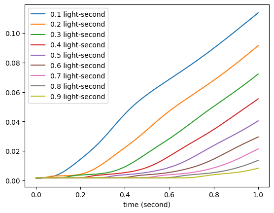

```python
plt.style.use('default')
ztpt=t.tensor(np.zeros([200,4]))
ztpt=ztpt.cuda()
for zloc in [0.1,0.2,0.3,0.4,0.5,0.6,0.7,0.8,0.9]:
    ztpt[:,0]=zloc
    ztpt[:,2]=np.pi
    ztpt[:,3]=t.tensor(np.linspace(0,1,num=200)).float().cuda()
    plt.plot(np.linspace(0,1,num=200),IntenNet(ztpt).cpu().detach().numpy(),label=str(round(zloc,3))+' light-second')
plt.legend()
plt.xlabel('time (second)')
```

### Rotational Conservation

Because the scattering phase function is only dependent on the zenith angle ($\phi_{bt}$), and the system is based on plane parallel approximation, the radiation field should not change under the different $\theta$ value. The predicted radiation intensity is slightly changing with $\theta$ angle.

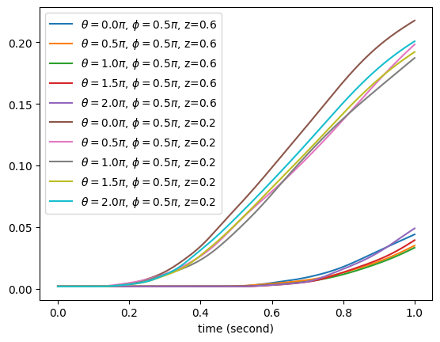

```python
plt.style.use('default')
ztpt=t.tensor(np.zeros([200,4]))
ztpt=ztpt.cuda()
for theta in [0,0.5*np.pi,np.pi,1.5*np.pi,2*np.pi]:
    ztpt[:,0]=0.6
    ztpt[:,1]=theta
    ztpt[:,2]=np.pi*0.5
    ztpt[:,3]=t.tensor(np.linspace(0,1,num=200)).float().cuda()
    plt.plot(np.linspace(0,1,num=200),IntenNet(ztpt).cpu().detach().numpy(),label=r'$\theta=$'+str(round(theta/np.pi,3))+r'$\pi$, $\phi=0.5\pi$, z=0.6')
for theta in [0,0.5*np.pi,np.pi,1.5*np.pi,2*np.pi]:
    ztpt[:,0]=0.2
    ztpt[:,1]=theta
    ztpt[:,2]=np.pi*0.5
    ztpt[:,3]=t.tensor(np.linspace(0,1,num=200)).float().cuda()
    plt.plot(np.linspace(0,1,num=200),IntenNet(ztpt).cpu().detach().numpy(),label=r'$\theta=$'+str(round(theta/np.pi,3))+r'$\pi$, $\phi=0.5\pi$, z=0.2')
plt.legend()
plt.xlabel('time (second)')
```

```python
t.save(IntenNet.state_dict(),'ExampleBoundary.to')
```